# IDS investigation worksheet

by YDTeam: Cecilia, Frank, Junkai, Zhandos

2025-11-27

**Note:** You can use this file as you ‘working document’ where you can try out various investigation ideas and keep notes about your findings. How you use and structure this file is up to you. It is recommended that you keep notes about what you are investigating and what you find as this will make the process of creating your presentation and report easier. Please note that you *do not* need to submit this file as part of your group project.

```r
library(tidyverse)
library(readr)

adjudications <- read_csv("data/CSV/AdjudicationsQ12023.csv")
```

```r
library(tidyverse)
library(janitor)
adjudications <- adjudications %>%
  clean_names()

adjudications_clean <- adjudications %>%
  drop_na()


adjudications_clean <- adjudications_clean %>%
  rename(quarter = date)


glimpse(adjudications_clean)
```

```
## Rows: 24,647
## Columns: 12
## $ quarter                               <chr> "Q1", "Q1", "Q1", "Q1", "Q1", "Q…
## $ outcomes                              <chr> "Dismissed", "Dismissed", "Dismi…
## $ predominant_function_of_establishment <chr> "Category A (High Security)", "C…
## $ establishment                         <chr> "Belmarsh", "Belmarsh", "Belmars…
## $ adjudicator                           <chr> "Governor", "Governor", "Governo…
## $ sex                                   <chr> "M", "M", "M", "M", "M", "M", "M…
## $ age_group                             <chr> "18 - 20", "18 - 20", "18 - 20",…
## $ ethnicity                             <chr> "b Black/ African/ Caribbean/ Bl…
## $ religion                              <chr> "a Christian", "a Christian", "a…
## $ offence                               <chr> "Disobedience/disrespect", "Viol…
## $ detailed_offence                      <chr> "Threats/Abusive and Insulting r…
## $ count                                 <dbl> 1, 1, 1, 1, 1, 1, 1, 1, 1, 3, 1,…
```

```r
colSums(is.na(adjudications_clean))
```

```
##                               quarter                              outcomes
##                                     0                                     0
## predominant_function_of_establishment                         establishment
##                                     0                                     0
##                           adjudicator                                   sex
##                                     0                                     0
##                             age_group                             ethnicity
##                                     0                                     0
##                              religion                               offence
##                                     0                                     0
##                      detailed_offence                                 count
##                                     0                                     0
```

Topic 1： Crime Patterns Across Age Groups in UK Prisons (Q1 2023) Question: What kinds of crimes are different age groups committing? introduction: Understanding how offence patterns vary across age groups is important for identifying behavioural trends within prisons. In the Adjudications dataset (Q1 2023), prisoners are classified into age groups, and each adjudication is associated with an offence category such as Disobedience/disrespect, Unauthorized transactions, or Violence. This section examines which age groups are responsible for particular types of offences and whether certain offences are more common among specific age ranges.

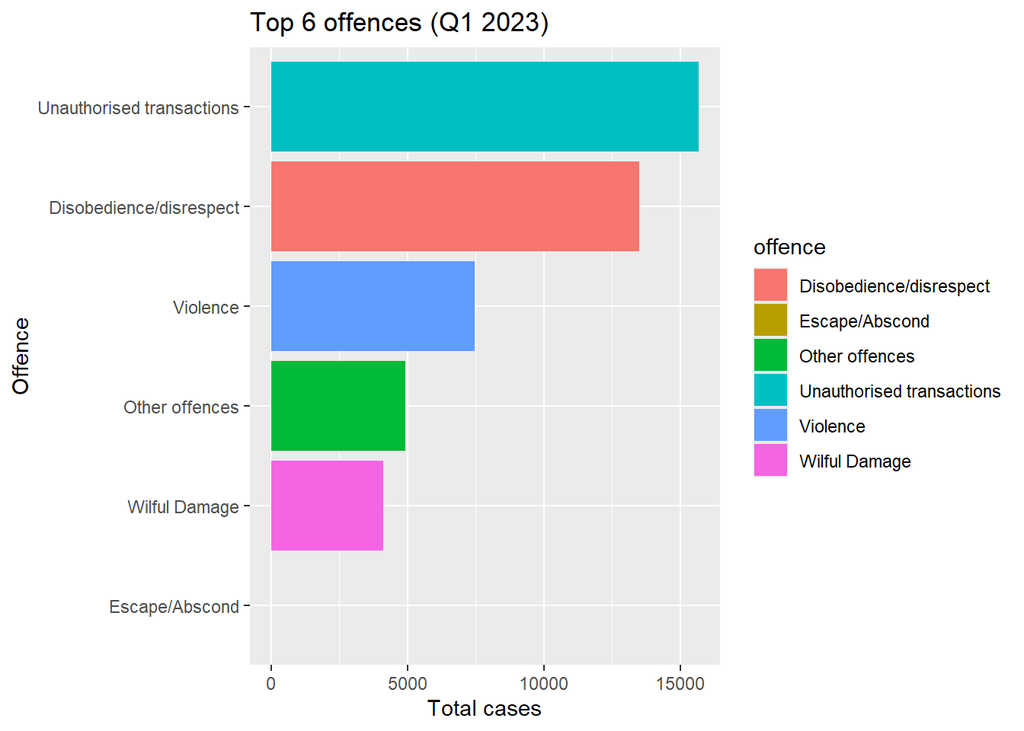

```r
library(dplyr)
library(ggplot2)


adjudications_clean %>%
  group_by(offence) %>%
  summarise(total = sum(count, na.rm = TRUE), .groups = "drop") %>%
  arrange(desc(total)) %>%
  slice_head(n = 6) %>%
  ggplot(aes(x = reorder(offence, total), y = total, fill = offence)) +
  geom_col() +
  coord_flip() +
  labs(
    title = "Top 6 offences (Q1 2023)",
    x = "Offence",
    y = "Total cases"
  )
```

```r
library(readr)
library(dplyr)
library(tidyr)
library(ggplot2)
library(stringr)
library(forcats)
library(scales)
library(gt)
library(glue)
library(janitor)


adj <- read_csv("AdjudicationsQ12023.csv") |> clean_names()
adj_clean <- adj |>
  rename(
    age_group = age_group,
    offence   = offence,
    count     = count
  ) |>
  mutate(
    count = suppressWarnings(as.numeric(count)),
    age_group = as.character(age_group),
    offence   = as.character(offence)
  ) |>
  filter(!is.na(age_group), !is.na(offence), !is.na(count), count > 0)


age_order <- c("15 - 17","18 - 20","21 - 24","25 - 29","30 - 39","40 - 49","50 - 59","60 - 69","70 and over")
adj_clean <- adj_clean |>
  mutate(age_group = fct_relevel(age_group, age_order, after = 0))

age_offence_counts <- adj_clean |>
  group_by(age_group, offence) |>
  summarise(total = sum(count), .groups = "drop")


age_totals <- age_offence_counts |>
  group_by(age_group) |>
  summarise(age_total = sum(total), .groups = "drop")


age_offence_share <- age_offence_counts |>
  left_join(age_totals, by = "age_group") |>
  mutate(pct = total / age_total)
top_offences <- adj_clean |>
  group_by(offence) |>
  summarise(total_cases = sum(count), .groups = "drop") |>
  arrange(desc(total_cases))

top_offences |>
  mutate(
    Rank  = row_number(),
    total_cases = comma(total_cases)
  ) |>
  select(Rank, offence, total_cases) |>
  gt() |>
  tab_header(title = md("**Top offences (Q1 2023)**")) |>
  cols_label(
    offence = "Offence",
    total_cases = "Total cases"
  )
```

**Top offences (Q1 2023)**

| Rank | Offence | Total cases |
| --- | --- | --- |
| 1 | Unauthorised transactions | 15,668 |
| 2 | Disobedience/disrespect | 13,511 |
| 3 | Violence | 7,470 |
| 4 | Other offences | 4,935 |
| 5 | Wilful Damage | 4,113 |
| 6 | Escape/Abscond | 8 |

```r
top3_by_age <- age_offence_share |>
  arrange(age_group, desc(total)) |>
  group_by(age_group) |>
  slice_head(n = 3) |>
  mutate(share = percent(pct, accuracy = 0.1)) |>
  ungroup() |>
  select(age_group, offence, total, share)

top3_by_age |>
  mutate(total = comma(total)) |>
  gt(groupname_col = "age_group") |>
  tab_header(title = md("**Top-3 offence types by age group**")) |>
  cols_label(
    offence = "Offence",
    total   = "Cases",
    share   = "Share"
  )
```

**Top-3 offence types by age group**

| Offence | Cases | Share |
| --- | --- | --- |
| 15 - 17 |  |  |
| Violence | 378 | 28.5% |
| Unauthorised transactions | 309 | 23.3% |
| Other offences | 252 | 19.0% |
| 18 - 20 |  |  |
| Violence | 1,358 | 30.0% |
| Disobedience/disrespect | 1,166 | 25.7% |
| Unauthorised transactions | 1,164 | 25.7% |
| 21 - 24 |  |  |
| Unauthorised transactions | 2,515 | 34.0% |
| Disobedience/disrespect | 2,031 | 27.5% |
| Violence | 1,476 | 20.0% |
| 25 - 29 |  |  |
| Unauthorised transactions | 3,440 | 35.5% |
| Disobedience/disrespect | 2,739 | 28.2% |
| Violence | 1,560 | 16.1% |
| 30 - 39 |  |  |
| Unauthorised transactions | 5,250 | 35.9% |
| Disobedience/disrespect | 4,559 | 31.2% |
| Violence | 1,814 | 12.4% |
| 40 - 49 |  |  |
| Unauthorised transactions | 2,218 | 38.8% |
| Disobedience/disrespect | 1,852 | 32.4% |
| Violence | 638 | 11.2% |
| 50 - 59 |  |  |
| Disobedience/disrespect | 769 | 39.9% |
| Unauthorised transactions | 625 | 32.5% |
| Violence | 203 | 10.5% |
| 60 - 69 |  |  |
| Disobedience/disrespect | 168 | 41.4% |
| Unauthorised transactions | 122 | 30.0% |
| Other offences | 48 | 11.8% |
| 70 and over |  |  |
| Disobedience/disrespect | 37 | 44.6% |
| Unauthorised transactions | 25 | 30.1% |
| Violence | 11 | 13.3% |

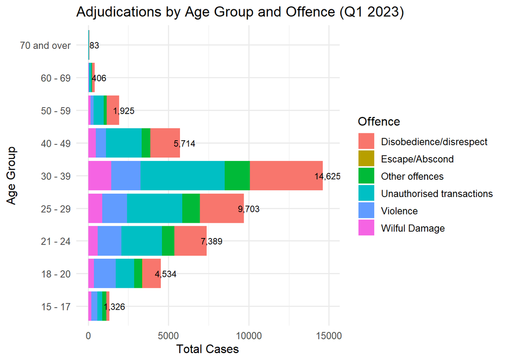

```r
p_counts <- age_offence_counts |>
  ggplot(aes(x = total, y = age_group, fill = offence)) +
  geom_col() +
  geom_text(
    data = age_totals,
    aes(x = age_total, y = age_group, label = comma(age_total)),
    nudge_x = max(age_totals$age_total, na.rm = TRUE) * 0.02,
    inherit.aes = FALSE, size = 3
  ) +
  labs(
    title = "Adjudications by Age Group and Offence (Q1 2023)",
    x = "Total Cases",
    y = "Age Group",
    fill = "Offence"
  ) +
  theme_minimal(base_size = 12)

p_counts
```

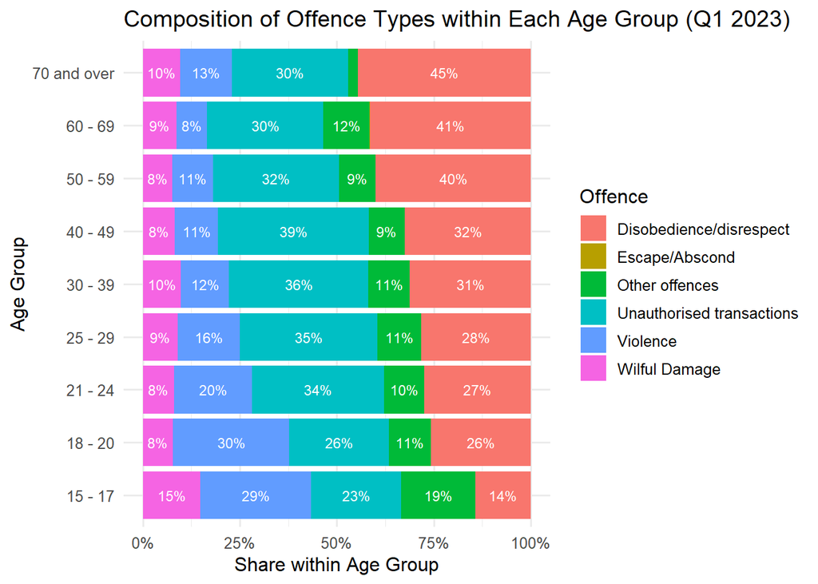

```r
# ggsave("age_offence_counts.png", p_counts, width = 9, height = 6, dpi = 300)

age_offence_share <- age_offence_counts |>
  dplyr::group_by(age_group) |>
  dplyr::mutate(age_total = sum(total),
                pct = total / age_total) |>
  dplyr::ungroup()


p_share_labels <- age_offence_share |>
  dplyr::mutate(lbl = ifelse(pct >= 0.05, scales::percent(pct, accuracy = 1), "")) |>
  ggplot(aes(x = pct, y = age_group, fill = offence)) +
  geom_col() +
  geom_text(
    aes(label = lbl),
    position = position_stack(vjust = 0.5),
    size = 3, color = "white"
  ) +
  scale_x_continuous(labels = scales::percent_format(accuracy = 1)) +
  labs(
    title = "Composition of Offence Types within Each Age Group (Q1 2023)",
    x = "Share within Age Group",
    y = "Age Group",
    fill = "Offence"
  ) +
  theme_minimal(base_size = 12)

p_share_labels
```

```r
# ggsave("age_offence_share.png", p_share_labels, width = 9, height = 6, dpi = 300)
```

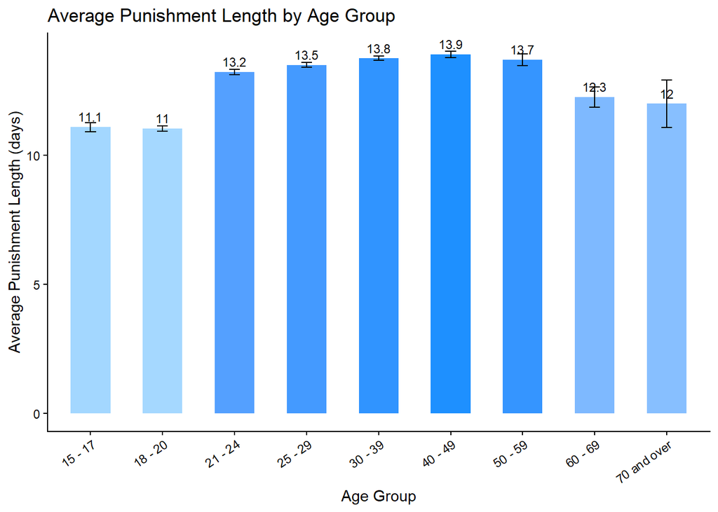

```r
library(dplyr)
library(ggplot2)
load("./data/CSV/punishments.rdata")

pun_clean <- punishments %>%
  rename(
    sex = Sex,
    age_group = `Age group`,
    no_days_raw = `No of days`
  ) %>%
  mutate(

    no_days_raw = ifelse(no_days_raw == ".", NA, no_days_raw),
    no_days = as.numeric(no_days_raw),
    sex = factor(sex),
    age_group = factor(age_group, ordered = TRUE)
  ) %>%
  filter(
    !is.na(sex),
    !is.na(age_group),
    !is.na(no_days),
    no_days > 0
  )
age_summary <- pun_clean %>%
  group_by(age_group) %>%
  summarise(
    mean_days = mean(no_days),
    se_days = sd(no_days) / sqrt(n())
  )
ggplot(age_summary, aes(x = age_group, y = mean_days, fill = mean_days)) +

  geom_col(width = 0.55) +


  geom_errorbar(
    aes(ymin = mean_days - se_days, ymax = mean_days + se_days),
    width = 0.15,
    linewidth = 0.5
  ) +


  geom_text(
    aes(label = round(mean_days, 1)),
    vjust = -0.6,
    size = 3
  ) +


  scale_fill_gradient(
    low = "#a5d8ff",
    high = "#1e90ff",
    name = "Mean days"
  ) +

  labs(
    title = "Average Punishment Length by Age Group",
    x = "Age Group",
    y = "Average Punishment Length (days)"
  ) +


  theme_classic(base_size = 11) +


  theme(
    axis.text.x = element_text(angle = 35, hjust = 1),
    legend.position = "none"
  )
```

```r
age_stats <- pun_clean %>%
  group_by(age_group) %>%
  summarise(
    n = n(),                 # 每组数量
    mean_days = mean(no_days),
    median_days = median(no_days),
    sd_days = sd(no_days),
    min_days = min(no_days),
    max_days = max(no_days),
    iqr_days = IQR(no_days)
  )

age_stats
```

```
## # A tibble: 9 × 8
##   age_group       n mean_days median_days sd_days min_days max_days iqr_days
##   <ord>       <int>     <dbl>       <dbl>   <dbl>    <dbl>    <dbl>    <dbl>
## 1 15 - 17       853      11.1          10    5.21        2       28        7
## 2 18 - 20      3753      11.0          10    6.05        1       42        7
## 3 21 - 24      5951      13.2          14    7.81        1       84        7
## 4 25 - 29      7202      13.5          14    7.97        1       84        7
## 5 30 - 39      9501      13.8          14    8.26        1       84        9
## 6 40 - 49      4081      13.9          14    7.82        1       50        7
## 7 50 - 59      1384      13.7          14    8.10        1       42        7
## 8 60 - 69       295      12.3          14    6.70        2       42        7
## 9 70 and over    47      12            14    6.34        3       28        7
```

```r
library(tidymodels)
# Convert offence categories into a binary classification variable (severe vs not_severe)
severe_levels <- c("Violence",
                   "Unauthorised transactions",
                   "Drug related offence")

pun_clean <- pun_clean %>%
  mutate(
    severe = if_else(Offence %in% severe_levels,
                     "severe", "not_severe"),
    severe = factor(severe, levels = c("not_severe", "severe"))
  )


# Fix random numbers by setting the seed
# Enables analysis to be reproducible when random numbers are used
set.seed(123)

# Put 80% of the data into the training set
data_split <- initial_split(pun_clean, prop = 0.8, strata = severe)
# Create data frames for the two sets:
data_train <- training(data_split)
data_test  <- testing(data_split)


#Fit a model to the training dataset
log_spec <-
  logistic_reg() %>%
  set_engine("glm")

severe_rec <- recipe(
  severe ~ age_group , # formula
  data = data_train) %>%                           # data to use for cataloguing names and types of variables
  step_dummy(all_nominal_predictors()) %>%   #Create dummy variables
  step_zv(all_predictors())        #Remove zero variance variables

summary(severe_rec)
```

```
## # A tibble: 2 × 4
##   variable  type      role      source
##   <chr>     <list>    <chr>     <chr>
## 1 age_group <chr [2]> predictor original
## 2 severe    <chr [3]> outcome   original
```

```r
severe_wf <-
  workflow() %>%
  add_recipe(severe_rec) %>%
  add_model(log_spec)


severe_fit <- severe_wf %>% fit(data = data_train)

tidy(severe_fit)
```

```
## # A tibble: 9 × 5
##   term        estimate std.error statistic   p.value
##   <chr>          <dbl>     <dbl>     <dbl>     <dbl>
## 1 (Intercept)  -0.0931    0.0445    -2.09  0.0367
## 2 age_group_1  -0.678     0.197     -3.44  0.000572
## 3 age_group_2   0.252     0.195      1.29  0.196
## 4 age_group_3   0.420     0.168      2.50  0.0123
## 5 age_group_4   0.458     0.135      3.40  0.000678
## 6 age_group_5   0.445     0.103      4.31  0.0000166
## 7 age_group_6   0.245     0.0742     3.30  0.000958
## 8 age_group_7   0.0177    0.0507     0.350 0.726
## 9 age_group_8  -0.0803    0.0327    -2.45  0.0141
```

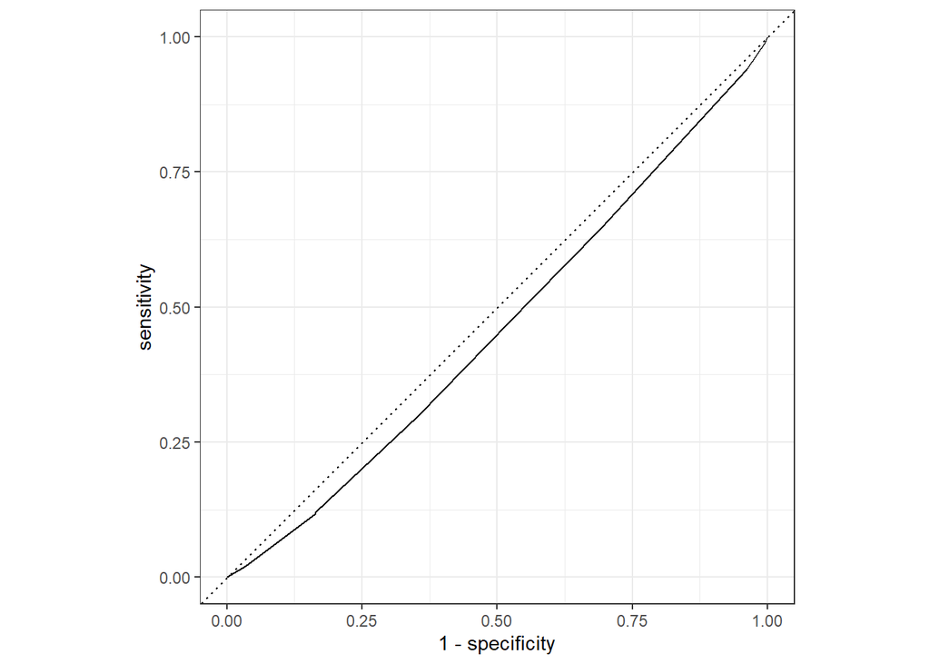

```r
#Predict probabilities on the testing dataset
severe_pred <-
  predict(severe_fit, data_test, type = "prob") %>%
  bind_cols(data_test %>% select(severe))


#create ROC diagram and calculate the area
roc_severe <-
  roc_curve(severe_pred, truth = severe, .pred_severe)

autoplot(roc_severe)
```

```r
auc_severe <-
  roc_auc(severe_pred, truth = severe, .pred_severe)

auc_severe
```

```
## # A tibble: 1 × 3
##   .metric .estimator .estimate
##   <chr>   <chr>          <dbl>
## 1 roc_auc binary         0.460
```

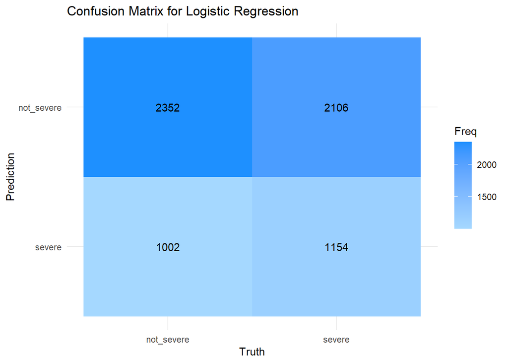

```r
library(yardstick)
library(ggplot2)

# 生成分类预测（分类结果而不是概率）
severe_pred_class <- predict(severe_fit, data_test) %>%
  bind_cols(data_test %>% select(severe))

# 混淆矩阵
conf_mat(severe_pred_class, truth = severe, estimate = .pred_class) %>%
  autoplot(type = "heatmap") +
  scale_fill_gradient(low = "#a5d8ff", high = "#1e90ff") +
  labs(title = "Confusion Matrix for Logistic Regression",
       x = "Truth",
       y = "Prediction") +
  theme_minimal()
```

```r
# 计算 sensitivity（查全率 / 召回率）
sensitivity(severe_pred_class, truth = severe, estimate = .pred_class)
```

```
## # A tibble: 1 × 3
##   .metric     .estimator .estimate
##   <chr>       <chr>          <dbl>
## 1 sensitivity binary         0.701
```

```r
# 计算 specificity（查准率）
specificity(severe_pred_class, truth = severe, estimate = .pred_class)
```

```
## # A tibble: 1 × 3
##   .metric     .estimator .estimate
##   <chr>       <chr>          <dbl>
## 1 specificity binary         0.354
```